# Lab 4: Data is Delicious

Author

Sydney Thompson

Github link: https://github.com/orsydney003/GSB_S544/tree/main/Lab4

## 1. Data from unstructured websites

This website contains many weekly meal plans. Choose one that seems delicious to you. Scrape the weekly meal plan into a table with the following columns:

- Day of the Week
- Name of Recipe
- Link to Recipe
- Price of Recipe

```python
import pandas as pd
import numpy as np
import requests
import re
from urllib.parse import urljoin
from bs4 import BeautifulSoup
```

```python
headers ={ "User-Agent": "Mozilla/5.0 (Windows NT 10.0; Win64; x64)" }

req = requests.Session()

# allows you to get the html content
response = req.get("https://tastesbetterfromscratch.com/meal-plan-197", headers=headers)

soup = BeautifulSoup(response.content, "html.parser")
```

```python
p_lines = len(soup.find_all("p"))
p_lines
```

```
38
```

```python
days = []
recipe_name = []
links = []
prices = []

# If meal items are in "<p>"
nodes = soup.select("p")

# used Chat GPT for exact regex expressions
# .compile() - takes a regex pattern and turns it into a reusable object
day_names = r"Monday|Tuesday|Wednesday|Thursday|Friday"
pattern = re.compile(rf"\b({day_names})\b:?\s*(.+?)\s*(?:\$\s*([\d,]+(?:\.\d{{1,2}})?))?\s*$", re.IGNORECASE)

base_url = "https://tastesbetterfromscratch.com/meal-plan-197"

for node in nodes:
  # normalize inner spacing
    text = node.get_text(" ", strip=True)
    m = pattern.search(text)
    if not m:
        continue

# looked up .capitalize()
# - only converts the first letter to an uppercase letter
# lstrip() - removes the ":" found when scraping
    day = m.group(1).capitalize()
    recipe = m.group(2).strip().lstrip(": ")
    price_text = m.group(3).strip() if m.group(3) else None

    # if a link is in the same node
    link_tag = node.find("a", href=True)
    recipe_url = urljoin(base_url, link_tag["href"]) if link_tag else None

    days.append(day)
    recipe_name.append(recipe)
    links.append(recipe_url)
    prices.append(price_text)

df_mealplan = pd.DataFrame({
    "Day of the Week": days,
    "Name of Recipe": recipe_name,
    "Link to Recipe": links,
    "Price of Recipe": prices
})
```

```python
df_mealplan
```

|  | Day of the Week | Name of Recipe | Link to Recipe | Price of Recipe |
| --- | --- | --- | --- | --- |
| 0 | Monday | Fettuccine Alfredo | https://tastesbetterfromscratch.com/fettuccine... | 7 |
| 1 | Tuesday | Clam Chowder | https://tastesbetterfromscratch.com/clam-chowder/ | 18.92 |
| 2 | Wednesday | Thai Basil Beef | https://tastesbetterfromscratch.com/thai-basil... | 13.45 |
| 3 | Thursday | Baked Tacos | https://tastesbetterfromscratch.com/baked-tacos/ | 16.26 |
| 4 | Friday | Pepperoni Pizza | https://tastesbetterfromscratch.com/pepperoni-... | 7.86 |

## 2. Data from an API

Using the Tasty API from the practice activity, search for recipes that match the “Monday” recipe in your meal plan. Compile a table of all these recipes.

(Warning - your free Tasty API account only allows 500 queries per month. You should not need more than this, but if you do end up with a recipe that has a large number of matches, you only need to scrape the first 100 of them.)

Hint: You may need to use some text editing tricks to convert the recipe name into a searchable string. Not all recipe names will find a match on the Tasty API; that’s okay and you can leave these blank.

```python
# extracting the monday recipe name from the df
monday_recipe = df_mealplan.loc[df_mealplan["Day of the Week"] == "Monday", "Name of Recipe"].iloc[0].strip(": ")
```

```python
monday_recipe
```

```
'Fettuccine Alfredo'
```

```python
url_tasty = "https://tasty.p.rapidapi.com/recipes/list?from=0&size=20"

# limit to 100 results
# using monday recipe as query
querystring = {"from": "0",
               "size": "100",
               "q": monday_recipe}

headers = {
    "X-RapidAPI-Key": "ca485a1d11mshb68f1a5d4bc7918p16884cjsn20d259aa23a7",
    "X-RapidAPI-Host": "tasty.p.rapidapi.com"
}

response = requests.get(url_tasty, headers=headers, params=querystring)

#print(response.json())

# normalize the JSON response into a DataFrame
fettucine_alfredo_recipes = pd.json_normalize(response.json(), "results")
```

```python
fettucine_alfredo_recipes['name']
```

```
0                One-Pot Cajun Fettuccine Alfredo Pasta
1                 Dairy-Free Chicken Fettuccine Alfredo
2                  Chicken Spinach Alfredo Rotini Pasta
3                           Garlic Shrimp Bacon Alfredo
4                        Chicken Bacon Broccoli Alfredo
5                        Vegan Fettuccine Alfredo Pasta
6     One-Pot Shrimp And Spinach Fettuccine Alfredo ...
7                   Dairy-Free Fettuccine Alfredo Pasta
8                          Shrimp Spinach Bacon Alfredo
9                            Lighter Fettuccine Alfredo
10              Fettuccine Alfredo–stuffed Garlic Bread
11                    Easy One-Pot Chicken Alfredo Soup
12                                      Pumpkin Alfredo
13                          Super Fast Mushroom Alfredo
14                                 Chicken Alfredo Soup
15            Healthy And Creamy Chicken Alfredo Recipe
Name: name, dtype: object
```

## 3. Automate it

Write a function called get_mealplan_data that performs 2 and 3 above automatically. That is, your function should:

Take as input a number 100-210, representing which weekly meal plan you are referencing.

Scrape the meal plan from the meal planning site.

Query the Tasty API for recipes matching each of the ones in the chosen weekly meal plan.

Output a single dataset, which contains all the information from the above

Hint: You may have an easier time if you write two smaller functions, get_weekly_plan and match_recipe, and then you use them inside your main function.

Run the following code, which should work if your function is complete:

df = get_mealplan_data(202)

```python
def get_weekly_plan(plan_num):
  """
  Scrapes a weekly plan from tastesbetterfromscratch.com
  Args: plan_num-> must be from 100-210

  Returns a DataFrame with columns: Week Day, Recipe Name, Link to Recipe, Recipe Price
  """
  # makes sure that plan is between 100-210
  # looked this up
  assert 100 <= plan_num <= 210

  recipe_url = f"https://tastesbetterfromscratch.com/meal-plan-{plan_num}/"
  headers = {"User-Agent": "Mozilla/5.0 (Windows NT 10.0; Win64; x64)"}
  html_content = requests.get(recipe_url, headers = headers).text
  soup = BeautifulSoup(html_content, "html.parser")

  recipes = []

  day_pattern = re.compile(r"^(monday|tuesday|wednesday|thursday|friday)\s*:?", re.I)

  for p in soup.select("div.entry-content p, div.entry-content li, p, li"):
    strong = p.find("strong")
    a = p.find("a", href = True)

    if not strong or not a:
      continue

    strong_text = strong.get_text(strip = True)
    if not day_pattern.match(strong_text):
      continue

    # finds the week day
    day = day_pattern.match(strong_text).group(1).capitalize()
    name = a.get_text(" ", strip = True)

    # finds the recipe name
    link = urljoin(recipe_url, a["href"])

    # finds the price of recipe
    p_text = " ".join(p.stripped_strings)
    m_price = re.search(r"\$([\d.,]+)", p_text)
    price = m_price.group(1) if m_price else None

    recipes.append({
      "Week Day": day,
      "Recipe Name": name,
      "Recipe Link": link,
      "Recipe Price": price
    })

  df = pd.DataFrame(recipes)

  # checks to make sure that the days of the week are in the "Week Day" column
  # enumerate() - can loop over an iterable and index at the same time
  if not df.empty and "Week Day" in df.columns:
    order = {d:i for i, d in enumerate(["Monday", "Tuesday", "Wednesday", "Thursday", "Friday"])}
    df = pd.DataFrame(recipes)

    df = df.sort_values(by = "Week Day", key = lambda s: s.map(order)).reset_index(drop = True)
  return df
```

```python
def match_recipe(recipe_name, limit = 100):
  """
  Uses Tasty (RapidAPI) to find matching recipes
  Returns a DF with a subset of columns
  """
  # pattern for query when looking at Tasty Recipes
  q = re.sub(r"[^A-Za-z0-9]+", " ", str(recipe_name)).strip().lower()

  # if pattern is not found, it will return an empty DataFrame()
  if not q:
    return pd.DataFrame()

    # query and RapidAPI
  url_tasty = "https://tasty.p.rapidapi.com/recipes/list"
  headers = {
    "X-RapidAPI-Key": "ca485a1d11mshb68f1a5d4bc7918p16884cjsn20d259aa23a7",
    "X-RapidAPI-Host": "tasty.p.rapidapi.com",
    "User-Agent": "Mozilla/5.0 (Windows NT 10.0; Win64; x64)"
  }

  output = []

# limits to only size 20 for queries
  for i in range(0, limit, 20):
    r = requests.get(url_tasty, headers = headers, params = {
      "from": str(i),
      "size": "20",
      "q": q})
# raise_for_status() - error checking -> raises an exception if the HTTP request failed
# had to do this because I kept getting an error
    r.raise_for_status()

    results = (r.json() or {}).get("results", []) or []
    if not results:
      break
    output.extend(results)
    if len(results) < 20:
      break

  if not output:
    return pd.DataFrame()

    # normalizing with json_normalize()
  df = pd.json_normalize(output)

# choosing which columns I wanted to extract from the json_normalize() results
  keep = [col for col in [
    "id", "name", "num_servings", "total_time_minutes", "nutrition.calories", "nutrition.sugar", "nutrition.protein", "nutrition.fiber", "nutrition.fat", "nutrition.carbohydrates"
    ] if col in df.columns]

  if not keep:
    return pd.DataFrame()

  df = df[keep].copy()

  # renaming columns for df
  df = df.rename(columns = {
    "name": "Tasty Recipe", "nutrition.calories": "calories", "nutrition.sugar": "sugar", "nutrition.protein": "protein", "nutrition.fiber": "fiber", "nutrition.fat": "fat", "nutrition.carbohydrates": "carbohydrates"})
  return df
```

```python
def get_mealplan_data(plan_num):
  plan_data = get_weekly_plan(plan_num)
  if plan_data.empty:
    print("Couldn't find any meals on this page.")
    return pd.DataFrame()

  all_rows = []

  for _, row in plan_data.iterrows():
    name = row["Recipe Name"]
    try:
      matches = match_recipe(name, limit = 100)
    except requests.HTTPError as e:
      matches = pd.DataFrame()

    if matches.empty:
      base = pd.DataFrame([{
        "id": None,
        "Tasty Recipe": None,
        "num_servings": None,
        "total_time_minutes": None,
        "calories": None,
        "carbohydrates": None,
        "sugar": None,
        "protein": None,
        "fat": None,
        "fiber": None
      }])

    else:
      base = matches

# inserts based on a specific position
# will add a new column
    base.insert(0, "Week Day", row["Week Day"])
    base.insert(1, "Recipe Name", row["Recipe Name"])
    base.insert(2, "Recipe Link", row["Recipe Link"])
    base.insert(3, "Recipe Price", row["Recipe Price"])
# will be used and appended to initialized list: all_rows
    all_rows.append(base)

    # filters out empty/all-NA frames to avoid the FutureWarning
    # i just wanted to get rid of this
  frames = [f for f in all_rows if not f.empty and not f.isna().all(axis=None)]
  if not frames:
    return pd.DataFrame()
  out = pd.concat(all_rows, ignore_index= True)

  desired_cols = ["Week Day", "Recipe Name", "Recipe Link", "Recipe Price", "id", "Tasty Recipe", "num_servings", "total_time_minutes", "calories", "protein", "fiber", "fat", "sugar", "carbohydrates"]

  out = out[[col for col in desired_cols if col in out.columns]]
  return out
```

```python
df = get_mealplan_data(202)
df
```

|  | Week Day | Recipe Name | Recipe Link | Recipe Price | id | Tasty Recipe | num_servings | total_time_minutes | calories | protein | fiber | fat | sugar | carbohydrates |
| --- | --- | --- | --- | --- | --- | --- | --- | --- | --- | --- | --- | --- | --- | --- |
| 0 | Monday | Chicken Divan | https://tastesbetterfromscratch.com/skinny-chi... | 10.82 | None | None | NaN | NaN | NaN | NaN | NaN | NaN | NaN | NaN |
| 1 | Tuesday | Beef Noodle Soup | https://tastesbetterfromscratch.com/beef-noodl... | 29.29 | 3822 | Taiwanese Beef Noodle Soup | 6.0 | 210.0 | 887.0 | 68.0 | 9.0 | 33.0 | 15.0 | 81.0 |
| 2 | Tuesday | Beef Noodle Soup | https://tastesbetterfromscratch.com/beef-noodl... | 29.29 | 7641 | Classic Lasagna Soup | 4.0 | 35.0 | 697.0 | 50.0 | 3.0 | 31.0 | 10.0 | 44.0 |
| 3 | Tuesday | Beef Noodle Soup | https://tastesbetterfromscratch.com/beef-noodl... | 29.29 | 3776 | Traditional Vietnamese Beef Pho | 8.0 | 480.0 | 539.0 | 27.0 | 3.0 | 20.0 | 3.0 | 59.0 |
| 4 | Tuesday | Beef Noodle Soup | https://tastesbetterfromscratch.com/beef-noodl... | 29.29 | 5464 | 1-Day Noodles (Taiwanese Beef Noodle Soup) | 8.0 | 0.0 | NaN | NaN | NaN | NaN | NaN | NaN |
| ... | ... | ... | ... | ... | ... | ... | ... | ... | ... | ... | ... | ... | ... | ... |
| 117 | Friday | Chicken Gyros | https://tastesbetterfromscratch.com/chicken-gy... | 21.22 | 642 | 5 Fork-less Finger Foods | NaN | NaN | NaN | NaN | NaN | NaN | NaN | NaN |
| 118 | Friday | Chicken Gyros | https://tastesbetterfromscratch.com/chicken-gy... | 21.22 | 2239 | Homemade American Street Foods | NaN | NaN | NaN | NaN | NaN | NaN | NaN | NaN |
| 119 | Friday | Chicken Gyros | https://tastesbetterfromscratch.com/chicken-gy... | 21.22 | 2463 | Chicken Recipes For The Whole Month | NaN | NaN | NaN | NaN | NaN | NaN | NaN | NaN |
| 120 | Friday | Chicken Gyros | https://tastesbetterfromscratch.com/chicken-gy... | 21.22 | 3370 | Tasty Dinners for Every Night of December | NaN | NaN | NaN | NaN | NaN | NaN | NaN | NaN |
| 121 | Friday | Chicken Gyros | https://tastesbetterfromscratch.com/chicken-gy... | 21.22 | 1368 | 11 Street Food Recipes You Can Make At Home | NaN | NaN | NaN | NaN | NaN | NaN | NaN | NaN |

122 rows × 14 columns

```python
# testing other mealplans below, but not assigning it to df
# will be commenting these out when rendering to html, but they do work
#get_mealplan_data(197)
```

```python
#get_mealplan_data(100)
```

```python
#get_mealplan_data(200)
```

## 4. Add a column with fuzzy matching

Add a column to your df dataset indicating whether the recipe in that row is vegetarian or not.

You may assume, for our purposes, that all recipes containing meat will have the name of a common meat in the recipe title. (Of course, that is not universally true - but we’ll assume it is for now.)

```python
import re

# pick a title per row
# if Tasty Recipe is there, choose this one
# otherwise use the Recipe Name column
title = (df.get("Tasty Recipe", pd.Series(pd.NA, index = df.index)).replace(r"^\s*$", pd.NA, regex = True).fillna(df["Recipe Name"]).astype(str))

# common meat words
meat_words = [
    "beef","steak","pork","ham","bacon","chicken","turkey","duck",
    "lamb","goat","veal","sausage","pepperoni","salami","chorizo",
    "fish","salmon","tuna","cod","shrimp","prawn","lobster","crab","clam", "scallop"]

# word-boundary regex that also works with plural forms
# # used Chat GPT for help with regex to find the exact pattern
pattern = re.compile(r"\b(?:" + "|".join(map(re.escape, meat_words)) + r")s?\b", re.IGNORECASE)

# creating a boolean column: True = vegetarian, False = not vegetarian
# basing it on recipe name and tasty recipe columns in df
df["Vegetarian"] = ~title.str.contains(pattern, na=False)
```

```python
# updating df by adding the df['Vegetarian'] column to it
df
```

|  | Week Day | Recipe Name | Recipe Link | Recipe Price | id | Tasty Recipe | num_servings | total_time_minutes | calories | protein | fiber | fat | sugar | carbohydrates | Vegetarian |
| --- | --- | --- | --- | --- | --- | --- | --- | --- | --- | --- | --- | --- | --- | --- | --- |
| 0 | Monday | Chicken Divan | https://tastesbetterfromscratch.com/skinny-chi... | 10.82 | None | None | NaN | NaN | NaN | NaN | NaN | NaN | NaN | NaN | False |
| 1 | Tuesday | Beef Noodle Soup | https://tastesbetterfromscratch.com/beef-noodl... | 29.29 | 3822 | Taiwanese Beef Noodle Soup | 6.0 | 210.0 | 887.0 | 68.0 | 9.0 | 33.0 | 15.0 | 81.0 | False |
| 2 | Tuesday | Beef Noodle Soup | https://tastesbetterfromscratch.com/beef-noodl... | 29.29 | 7641 | Classic Lasagna Soup | 4.0 | 35.0 | 697.0 | 50.0 | 3.0 | 31.0 | 10.0 | 44.0 | True |
| 3 | Tuesday | Beef Noodle Soup | https://tastesbetterfromscratch.com/beef-noodl... | 29.29 | 3776 | Traditional Vietnamese Beef Pho | 8.0 | 480.0 | 539.0 | 27.0 | 3.0 | 20.0 | 3.0 | 59.0 | False |
| 4 | Tuesday | Beef Noodle Soup | https://tastesbetterfromscratch.com/beef-noodl... | 29.29 | 5464 | 1-Day Noodles (Taiwanese Beef Noodle Soup) | 8.0 | 0.0 | NaN | NaN | NaN | NaN | NaN | NaN | False |
| ... | ... | ... | ... | ... | ... | ... | ... | ... | ... | ... | ... | ... | ... | ... | ... |
| 117 | Friday | Chicken Gyros | https://tastesbetterfromscratch.com/chicken-gy... | 21.22 | 642 | 5 Fork-less Finger Foods | NaN | NaN | NaN | NaN | NaN | NaN | NaN | NaN | True |
| 118 | Friday | Chicken Gyros | https://tastesbetterfromscratch.com/chicken-gy... | 21.22 | 2239 | Homemade American Street Foods | NaN | NaN | NaN | NaN | NaN | NaN | NaN | NaN | True |
| 119 | Friday | Chicken Gyros | https://tastesbetterfromscratch.com/chicken-gy... | 21.22 | 2463 | Chicken Recipes For The Whole Month | NaN | NaN | NaN | NaN | NaN | NaN | NaN | NaN | False |
| 120 | Friday | Chicken Gyros | https://tastesbetterfromscratch.com/chicken-gy... | 21.22 | 3370 | Tasty Dinners for Every Night of December | NaN | NaN | NaN | NaN | NaN | NaN | NaN | NaN | True |
| 121 | Friday | Chicken Gyros | https://tastesbetterfromscratch.com/chicken-gy... | 21.22 | 1368 | 11 Street Food Recipes You Can Make At Home | NaN | NaN | NaN | NaN | NaN | NaN | NaN | NaN | True |

122 rows × 15 columns

## 5. Analyze

Make a visualization that tells a story about nutrition information (available in the Tasty API results) across the week for Mealplan 202. Your visualization should also indicate which meals are vegetarian.

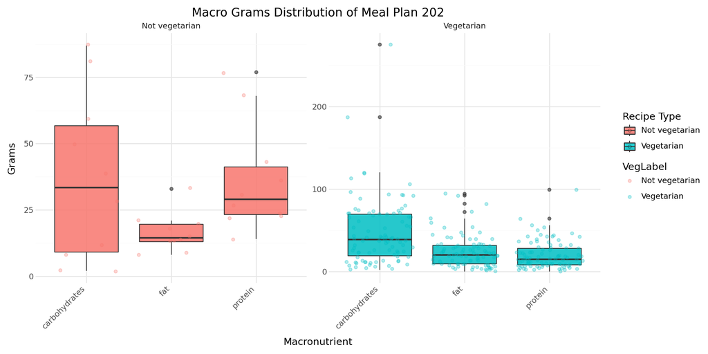

```python
import plotnine as p9
from plotnine import *

# make sure the three macro columns exist & numeric
for c in ["protein", "fat", "carbohydrates"]:
    df[c] = pd.to_numeric(df.get(c), errors="coerce")

# consistent day order
day_order = ["Monday","Tuesday","Wednesday","Thursday","Friday"]
df["Week Day"] = pd.Categorical(df["Week Day"], categories=day_order, ordered=True)

# use a no-space, consistent label column
df["VegLabel"] = df["Vegetarian"].map({True: "Vegetarian", False: "Not vegetarian"})

# tidy long
tidy_df = df.melt(
    id_vars=["Week Day","VegLabel"],
    value_vars=["protein","fat","carbohydrates"],
    var_name="Nutrient",
    value_name="grams"
)

# boxplot per day, faceted by Nutrient
macro_nutrient_plot = (
    ggplot(tidy_df, aes(x="Nutrient", y="grams", fill="VegLabel"))
    + geom_boxplot(outlier_shape="o", outlier_alpha=0.6, alpha=0.85)
    + geom_jitter(aes(color="VegLabel"), alpha = 0.3)
    + facet_wrap("~VegLabel", ncol=2, scales="free_y")
    + labs(
        title="Macro Grams Distribution of Meal Plan 202",
        x="Macronutrient", y="Grams", fill="Recipe Type"
    )
    + theme_minimal()
    + theme(
        figure_size=(11, 5.5),
        axis_text_x=element_text(rotation=45, ha="right")
    )
)
macro_nutrient_plot
```